# “**COMPSCIX 415.2 Homework 6**”

Santosh Kanutala

7/17/2018

## Github location

My homework assignments can be found at https://github.com/santumagic/compscix-415-2assignments.git

## Exercise 1

### Question: 1

```r
# Load the required packages
library(tidyverse)
library(mdsr)
library(mosaicData)
# glimpse the given dataset
glimpse(Whickham)
```

```
## Observations: 1,314
## Variables: 3
## $ outcome <fct> Alive, Alive, Dead, Alive, Alive, Alive, Alive, Dead, ...
## $ smoker  <fct> Yes, Yes, Yes, No, No, Yes, Yes, No, No, No, No, Yes, ...
## $ age     <int> 23, 18, 71, 67, 64, 38, 45, 76, 28, 27, 28, 34, 20, 72...
```

**Answer:**  
Below are the three variables from the Whickham dataset.

- outcome
- smoker
- age

### Question: 2

**Answer:**  
There are 1314 observations. Each observation represents a person. The data set indicates if the individual is a smoker or not, current age an individual, and if the individual is alive or dead.

### Question: 3

```r
library(mosaicData)
library(tidyverse)
Whickham %>% count( smoker , outcome )
```

```
## # A tibble: 4 x 3
##   smoker outcome     n
##   <fct>  <fct>   <int>
## 1 No     Alive     502
## 2 No     Dead      230
## 3 Yes    Alive     443
## 4 Yes    Dead      139
```

**Answer:**  
By looking at the above table, it is difficult to conclude anything, so I calculate the proportions first by using the below code.

```r
Whickham_proportions <- Whickham %>% group_by(smoker,outcome) %>%
  summarize(n = n()) %>%
  mutate ( prop = n/sum(n))
 Whickham_proportions
```

```
## # A tibble: 4 x 4
## # Groups:   smoker [2]
##   smoker outcome     n  prop
##   <fct>  <fct>   <int> <dbl>
## 1 No     Alive     502 0.686
## 2 No     Dead      230 0.314
## 3 Yes    Alive     443 0.761
## 4 Yes    Dead      139 0.239
```

By looking at the above proportions it is observed that, 31.4 % of non smokers are dead and 23.8 % of smokers are dead which means more healthy people are dead. So there must be other reasons for deaths or data might be wrong. So the data doesn’t make any sense.

### Question: 4

```r
# creating the age groups column
Whickham_factor <- Whickham %>% mutate (category =
                                          factor (
case_when(age <= 44 ~ "age <= 44", age > 44 & age <= 64 ~ "age > 44 & age <= 64",
          age > 64 ~ "age > 64")))

head(Whickham_factor) # display the top rows of the result dataset
```

```
##   outcome smoker age             category
## 1   Alive    Yes  23            age <= 44
## 2   Alive    Yes  18            age <= 44
## 3    Dead    Yes  71             age > 64
## 4   Alive     No  67             age > 64
## 5   Alive     No  64 age > 44 & age <= 64
## 6   Alive    Yes  38            age <= 44
```

```r
# reorganize the data by grouping,summarise the data and finding the proportions
Whickham_cat <- Whickham_factor %>%
group_by(category,smoker,outcome) %>% summarise( n = n()) %>%
mutate (proportion = n/sum(n))

head(Whickham_cat) # display the top rows of the result dataset
```

```
## # A tibble: 6 x 5
## # Groups:   category, smoker [3]
##   category             smoker outcome     n proportion
##   <fct>                <fct>  <fct>   <int>      <dbl>
## 1 age <= 44            No     Alive     327     0.965
## 2 age <= 44            No     Dead       12     0.0354
## 3 age <= 44            Yes    Alive     270     0.947
## 4 age <= 44            Yes    Dead       15     0.0526
## 5 age > 44 & age <= 64 No     Alive     147     0.735
## 6 age > 44 & age <= 64 No     Dead       53     0.265
```

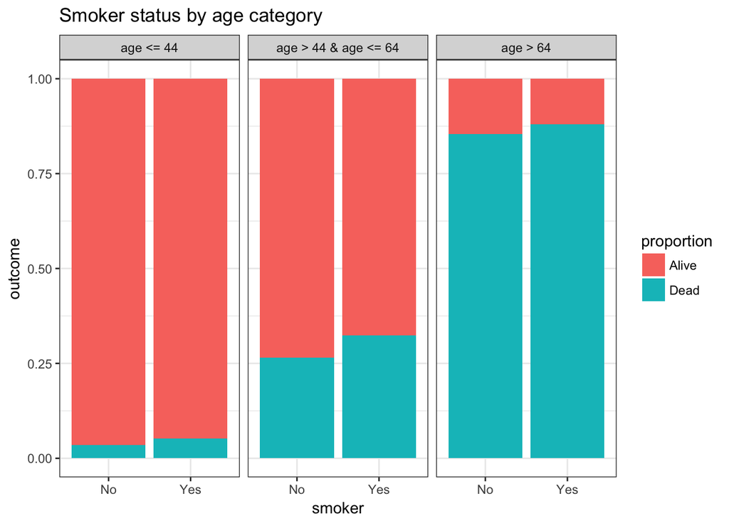

```r
# create the visualization with the above result set and facet on age categories
Whickham_cat %>%
ggplot() +
  geom_bar(aes(x = smoker, y = proportion, fill = outcome, label = round(proportion,2)),
           stat = 'identity', position = 'fill') +
  labs(x = 'smoker', y = 'outcome', fill = 'proportion',
       title = 'Smoker status by age category') +
  facet_grid(~ category) +
  theme_bw()
```

## Exercise 2

### Question: 1

```r
# given sample code
library(tidyverse)
n <- 10000
# look at ?rgamma to read about this function
gamma_samp <- tibble(x = rgamma(n, shape = 1, scale = 2))
gamma_samp
```

```
## # A tibble: 10,000 x 1
##         x
##     <dbl>
##  1 6.86
##  2 2.96
##  3 3.52
##  4 1.41
##  5 1.91
##  6 2.32
##  7 0.0667
##  8 1.21
##  9 3.88
## 10 1.16
## # ... with 9,990 more rows
```

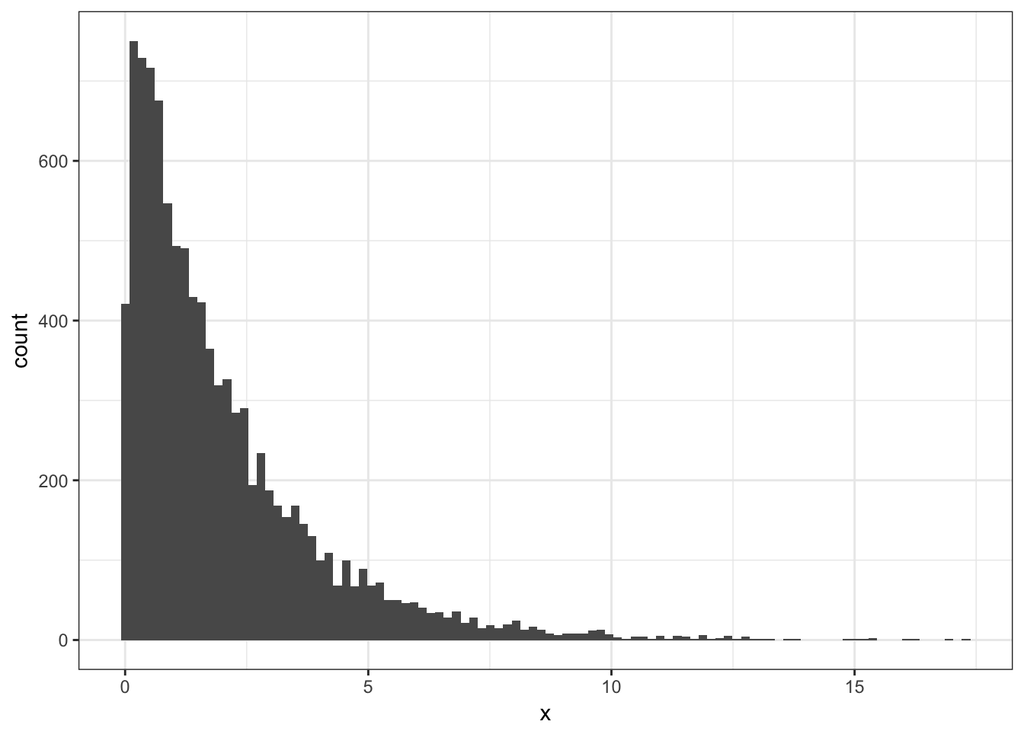

```r
# histogram for the above sample gamma
ggplot(data = gamma_samp) +
  geom_histogram(aes(x=x), bins=100) +
  theme_bw()
```

### Question: 2

```r
# finding mean
sprintf ("Mean = %f",sapply(gamma_samp, mean, na.rm = TRUE))
```

```
## [1] "Mean = 1.990962"
```

```r
# finding standard deviation
sprintf ("Standard deviation = %f", sapply(gamma_samp, sd, na.rm = TRUE))
```

```
## [1] "Standard deviation = 1.999553"
```

### Question: 3

```r
# sample of size n = 30
sample_30 <- gamma_samp %>% sample_n(30, replace = TRUE)

# finding mean
sprintf("Mean = %f", sapply(sample_30, mean, na.rm = TRUE))
```

```
## [1] "Mean = 2.136314"
```

```r
# finding standard deviation
sprintf ("Standard deviation = %f", sapply(sample_30, sd, na.rm = TRUE))
```

```
## [1] "Standard deviation = 2.268548"
```

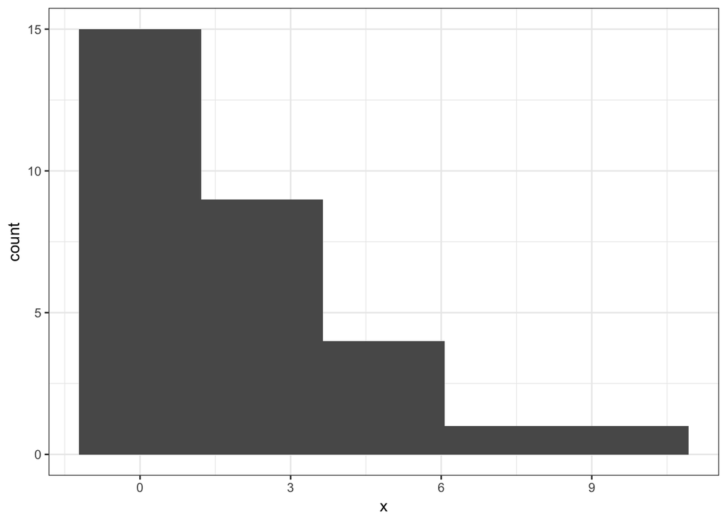

```r
# Plot the histogram
ggplot(data =sample_30, mapping = aes(x=x)) +
  geom_histogram(bins=5) +
  theme_bw()
```

### Question: 4

```r
mean_samp <- rep(NA, 10000)

mean_sd <- rep(NA, 10000)
for (i in 1:10000) {
g_samp <- gamma_samp %>%
  sample_n(30, replace = TRUE)
mean_samp[i] <- mean(g_samp$x)
mean_sd[i] <- sd(g_samp$x)
}
# tibbles for mean_samp and mead_sd
mean_samp_tibble <- tibble(mean_samp)
mean_sd_tibble <- tibble(mean_sd)
mean_dist <- bind_cols(mean_samp_tibble,mean_sd_tibble)

# display the sample of final vector
head(mean_dist)
```

```
## # A tibble: 6 x 2
##   mean_samp mean_sd
##       <dbl>   <dbl>
## 1      1.62    1.54
## 2      2.16    2.07
## 3      1.90    1.63
## 4      1.74    1.80
## 5      2.00    2.04
## 6      2.18    2.31
```

### Question: 5

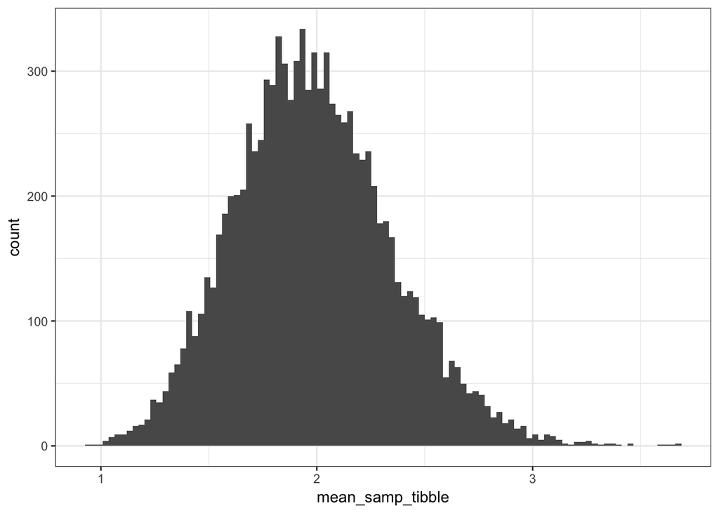

```r
# plot for the means
ggplot(data = mean_dist, mapping = aes(x=mean_samp_tibble)) +
  geom_histogram(bins=100) +
  theme_bw()
```

### Question: 6

```r
# from the code of Question 4 : below are sample of the standard deviations of the population
head(mean_sd_tibble)
```

```
## # A tibble: 6 x 1
##   mean_sd
##     <dbl>
## 1    1.54
## 2    2.07
## 3    1.63
## 4    1.80
## 5    2.04
## 6    2.31
```

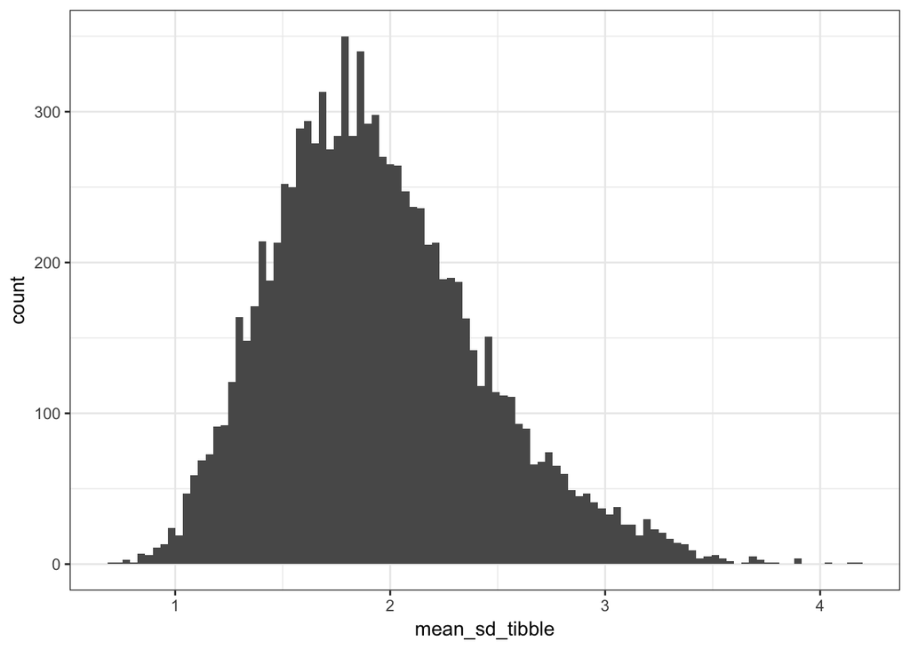

```r
# plot for the standard deviation
ggplot(data = mean_dist, mapping = aes(x=mean_sd_tibble)) +
  geom_histogram(bins=100) +
  theme_bw()
```

### Question: 7

**Answer:** Both the mean and sd plots of the population looks normally distributed.

### Question: 8

```r
# Repeat Question 4 with sample size = 300
mean_samp_300 <- rep(NA, 10000)

mean_sd_300 <- rep(NA, 10000)
for (i in 1:10000) {
g_samp_300 <- gamma_samp %>%
  sample_n(300, replace = TRUE)
mean_samp_300[i] <- mean(g_samp_300$x)
mean_sd_300[i] <- sd(g_samp_300$x)
}
# tibbles for mean_samp and mead_sd
mean_samp_tibble_300 <- tibble(mean_samp_300)
mean_sd_tibble_300 <- tibble(mean_sd_300)
mean_dist_300 <- bind_cols(mean_samp_tibble_300,mean_sd_tibble_300)
# display the sample of final vector
head(mean_dist_300)
```

```
## # A tibble: 6 x 2
##   mean_samp_300 mean_sd_300
##           <dbl>       <dbl>
## 1          2.22        2.38
## 2          1.98        1.92
## 3          2.03        1.85
## 4          1.95        1.98
## 5          1.78        1.63
## 6          1.87        1.78
```

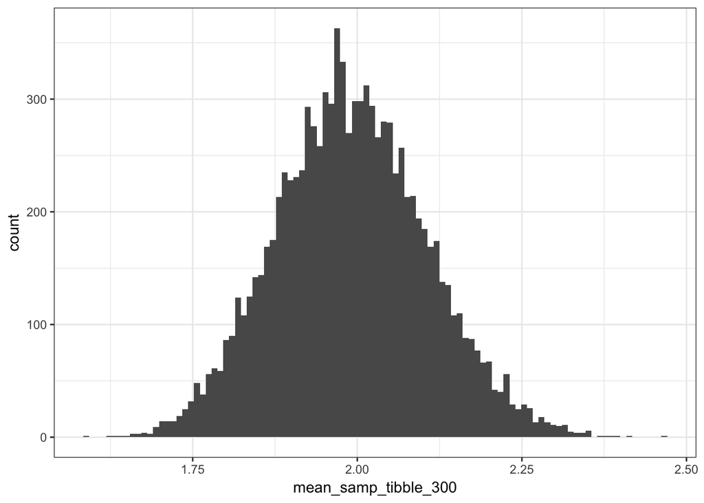

```r
# plot for the means_300
ggplot(data = mean_dist_300, mapping = aes(x=mean_samp_tibble_300)) +
  geom_histogram(bins=100) +
  theme_bw()
```

```r
# Repeat Question 6 with sample size = 300

# below are sample of the standard deviations of the population
head(mean_sd_tibble_300)
```

```
## # A tibble: 6 x 1
##   mean_sd_300
##         <dbl>
## 1        2.38
## 2        1.92
## 3        1.85
## 4        1.98
## 5        1.63
## 6        1.78
```

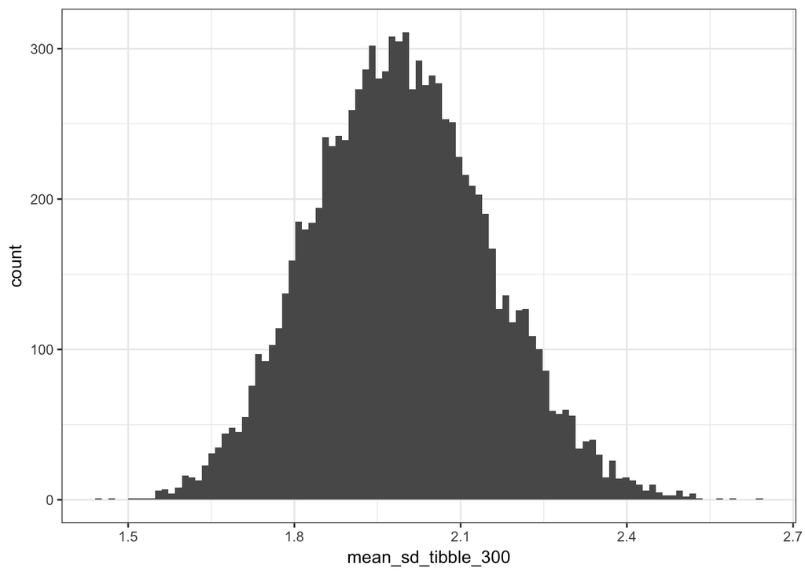

```r
# plot for the standard deviation
ggplot(data = mean_dist_300, mapping = aes(x=mean_sd_tibble_300)) +
  geom_histogram(bins=100) +
  theme_bw()
```

**Answer:** Even with the sample size of 300, the distributions of means and sd are looking normally distributed to me.